# Demonstration of Caret Package for Implementation of Supervised Machine Learning

JAS

July 12, 2021

## Overview of the Caret Package

The caret package (Classification And REgression Training) contains a number of functions to streamline the process for creating analytic pipelines for prediction. It calls to other libraries to run algorithms, but provides a seamless and uniform interface for working with different algorithms.

Primary functionalities of caret include:

- pre-processing
- data splitting
- feature selection
- model tuning using resampling
- variable importance estimation

Helpful resources using caret:

Max Kuhn’s explainer of the caret package https://topepo.github.io/caret/model-training-and-tuning.html

Kuhn M. Building predictive models in R using the caret package. Journal of Statistical Software 2008;28(5) doi: 10.18637/jss.v028.i05

Webinar, given by Max Kuhn, available on YouTube (~1 hour): https://www.youtube.com/watch?v=7Jbb2ItbTC4

### Description of Data Used during Demonstration

Data Source: UCI Machine Learning Repository, HCV data Dataset

The dataset contains laboratory values of blood donors (control) and Hepatitis C patients with varying levels of liver damage. Created by Lichtinghagen, Klawonn and Hoffmann. Lichtinghagen R et al. J Hepatol 2013; 59: 236-42

Attribute Information:

All attributes except Category and Sex are numerical. The laboratory data are the attributes 5-14. 1) X (Patient ID/No.) 2) Category (diagnosis) (values: ‘0=Blood Donor’, ‘0s=suspect Blood Donor’, ‘1=Hepatitis’, ‘2=Fibrosis’, ‘3=Cirrhosis’) 3) Age (in years) 4) Sex (f,m) 5) ALB 6) ALP 7) ALT 8) AST 9) BIL 10) CHE 11) CHOL 12) CREA 13) GGT 14) PROT

Research question: Can we distinguish individuals with Hepatitis C (with or without more severe liver damage) from blood donors? (Source: Kaggle https://www.kaggle.com/fedesoriano/hepatitis-c-dataset/code) ***

### Loading Packages and Data Cleaning

```r
library(tidyverse)
library(caret)
library(stats)

#Read in data on liver function study
set.seed(111)
hcvdat0 <- read.csv("C:/Users/js5406/Downloads/hcvdat0.csv")
#hcvdat0<-read.csv("Data/hcvdat0.csv")

#Make outcome category a factor var
hcvdat0$Category<-as.factor(hcvdat0$Category)

#Collapse factor levels of outcome variable
hcvdat0$outcome.class<-fct_collapse(hcvdat0$Category, NED=c("0=Blood Donor","0s=suspect Blood Donor"), LiverDisease=c("1=Hepatitis", "2=Fibrosis", "3=Cirrhosis"))

#Drop category and ID variable and remove missings
hcvdat0$Category<-NULL
hcvdat0$X<-NULL
hcvdat0<-na.omit(hcvdat0)
```

### Examples of pre-processing functions

Caret contains a number of pre-processing functions that can be helpful as you implement your analytic pipeline. These functions can be used in combination (and sometimes within) caret functions intended for training a model or can be implemented separately before using another R package. Below is code for identifying highly correlated features, centering and scaling numeric data and partitioning data.

```r
#Finding correlated predictors
hcvdat.numeric<- hcvdat0 %>% dplyr::select(where(is.numeric))
correlations<-cor(hcvdat.numeric, use="complete.obs")
high.correlations<-findCorrelation(correlations, cutoff=0.4)

#Centering and Scaling
set.up.preprocess<-preProcess(hcvdat.numeric, method=c("center", "scale"))
#Output pre-processed values
transformed.vals<-predict(set.up.preprocess, hcvdat.numeric)

#Creating balanced partitions in the data
train.index<-createDataPartition(hcvdat0$outcome.class, p=0.7, list=FALSE)

hcvdat.train<-hcvdat0[train.index,]
hcvdat.test<-hcvdat0[-train.index,]

#Construct k-folds in your data
train.folds<-createFolds(hcvdat0$outcome.class, k=10, list=FALSE)
```

### Model Training and Tuning

Caret primarily uses the train function to implement the training of the model, including tuning hyperparameters.

```r
#See what caret can do!
names(getModelInfo())
```

```
##   [1] "ada"                 "AdaBag"              "AdaBoost.M1"
##   [4] "adaboost"            "amdai"               "ANFIS"
##   [7] "avNNet"              "awnb"                "awtan"
##  [10] "bag"                 "bagEarth"            "bagEarthGCV"
##  [13] "bagFDA"              "bagFDAGCV"           "bam"
##  [16] "bartMachine"         "bayesglm"            "binda"
##  [19] "blackboost"          "blasso"              "blassoAveraged"
##  [22] "bridge"              "brnn"                "BstLm"
##  [25] "bstSm"               "bstTree"             "C5.0"
##  [28] "C5.0Cost"            "C5.0Rules"           "C5.0Tree"
##  [31] "cforest"             "chaid"               "CSimca"
##  [34] "ctree"               "ctree2"              "cubist"
##  [37] "dda"                 "deepboost"           "DENFIS"
##  [40] "dnn"                 "dwdLinear"           "dwdPoly"
##  [43] "dwdRadial"           "earth"               "elm"
```

[output cut: 65 more lines]

```r
modelLookup("rpart")
```

```
##   model parameter                label forReg forClass probModel
## 1 rpart        cp Complexity Parameter   TRUE     TRUE      TRUE
```

```r
modelLookup("adaboost")
```

```
##      model parameter  label forReg forClass probModel
## 1 adaboost     nIter #Trees  FALSE     TRUE      TRUE
## 2 adaboost    method Method  FALSE     TRUE      TRUE
```

```r
#Train Function: used for tuning of hyperparameters and choosing "optimal" model

#Use trainControl Function to set validation method and options (default is bootstrap)

#Perform 10-fold cross-validation
control.settings<-trainControl(method="cv", number=10)

#Perform repeated 10-fold cross-validation
control.settings.b<-trainControl(method="repeatedcv", number=10, repeats=10)

#Perform sampling to balance data
control.settings.c<-trainControl(method="repeatedcv", number=10, repeats=10, sampling="down")

#Train function can be used to implement different algorithms using method=

#Demonstration of LASSO Algorithm using glmnet

#modelLookup will specify hyperparameters

modelLookup("glmnet")
```

```
##    model parameter                    label forReg forClass probModel
## 1 glmnet     alpha        Mixing Percentage   TRUE     TRUE      TRUE
## 2 glmnet    lambda Regularization Parameter   TRUE     TRUE      TRUE
```

```r
set.seed(123)

lasso <- train(
 outcome.class ~., data = hcvdat.train, method = "glmnet", preProc=c("center", "scale"),
  trControl = control.settings.c)

lasso$results
```

```
##   alpha       lambda  Accuracy     Kappa AccuracySD   KappaSD
## 1  0.10 0.0003724051 0.9623113 0.8093764 0.03043638 0.1468820
## 2  0.10 0.0037240514 0.9697967 0.8376007 0.02651441 0.1357007
## 3  0.10 0.0372405144 0.9644657 0.8006567 0.02720223 0.1498006
## 4  0.55 0.0003724051 0.9596632 0.7975111 0.03151669 0.1438344
## 5  0.55 0.0037240514 0.9702904 0.8424544 0.02771447 0.1376093
## 6  0.55 0.0372405144 0.9661556 0.8142645 0.02680987 0.1355880
## 7  1.00 0.0003724051 0.9557549 0.7842365 0.03290237 0.1400820
## 8  1.00 0.0037240514 0.9758304 0.8690277 0.02311057 0.1216791
## 9  1.00 0.0372405144 0.9763415 0.8663142 0.02194517 0.1175182
```

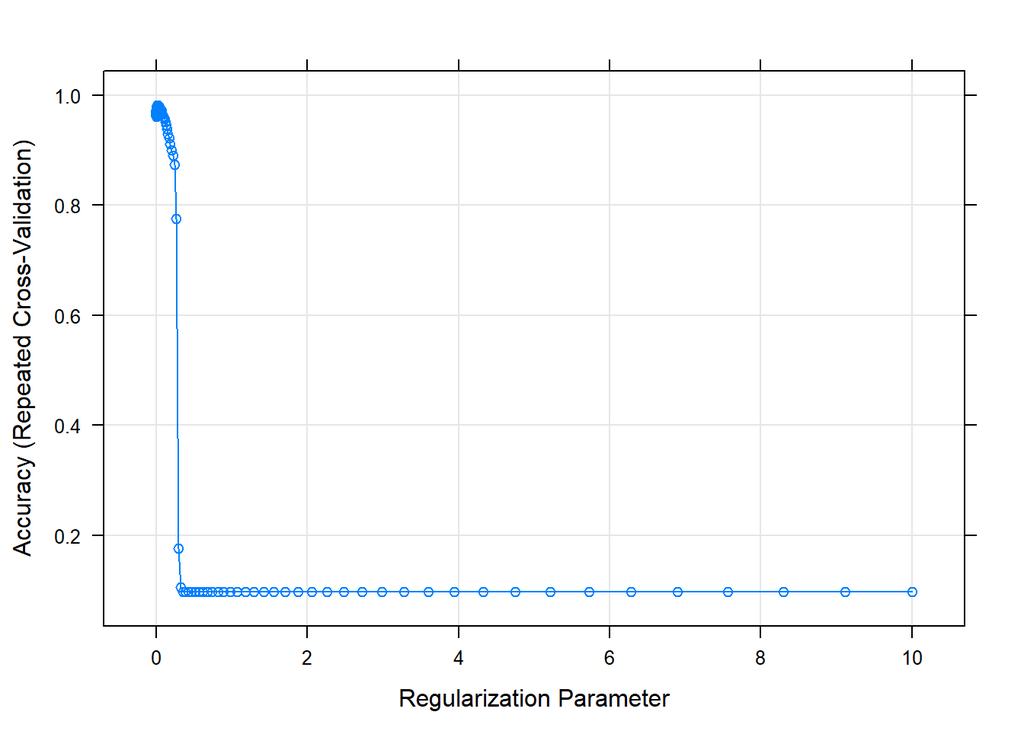

```r
#Don't depend on defaults for hyperparameters. Add tuning grid for lambda and alpha (but set alpha to 1 for LASSO)
lambda<-10^seq(-3,1, length=100)
lambda.grid<-expand.grid(alpha=1, lambda=lambda)

#Incorporate tuneGrid into train function
set.seed(123)
lasso.2 <- train(
 outcome.class ~., data = hcvdat.train, method = "glmnet",preProc=c("center", "scale"),
  trControl = control.settings.c, tuneGrid = lambda.grid)


#Use plot to visualize tuning
plot(lasso.2)
```

```r
#summaryFunction will allow calculation of sensitivity and specificity, classProbs= TRUE will allow the calculation of predicted probabilities

control.settings.d<-trainControl(method="repeatedcv", number=10, repeats=5, sampling="down", classProbs = TRUE, summaryFunction = twoClassSummary)

#Incorporate tuneGrid into train function and change evaluation metric to area under ROC curve
set.seed(123)
lasso.3 <- train(
 outcome.class ~., data = hcvdat.train, method = "glmnet",preProc=c("center", "scale"),
  trControl = control.settings.d, tuneGrid = lambda.grid, metric="ROC")

lasso.3$bestTune
```

```
##    alpha     lambda
## 33     1 0.01963041
```

```r
#The tolerance function could be used to find a less complex model based on (x-xbest)/xbestx 100, which is #the percent difference. For example, to select parameter values based on a 2% loss of performance. Similar function (oneSE) would find optimal tuning within 1 standard error. Use of these functions is to avoid overfitting.

whichTwoPct <- tolerance(lasso.3$results, metric = "ROC",
                         tol = 2, maximize = TRUE)

lasso.3$results[whichTwoPct,1:6]
```

```
##   alpha      lambda       ROC      Sens  Spec      ROCSD
## 6     1 0.001592283 0.9543492 0.9716358 0.905 0.09435761
```

### Model Evaluation

Caret has built in functions to evaluate the performance of your model.

```r
test.outcome<-predict(lasso.3, hcvdat.test)

confusionMatrix(test.outcome, hcvdat.test$outcome, positive="LiverDisease")
```

```
## Confusion Matrix and Statistics
##
##               Reference
## Prediction     NED LiverDisease
##   NED          156            4
##   LiverDisease   3           12
##
##                Accuracy : 0.96
##                  95% CI : (0.9193, 0.9838)
##     No Information Rate : 0.9086
##     P-Value [Acc > NIR] : 0.007667
##
##                   Kappa : 0.7523
##
##  Mcnemar's Test P-Value : 1.000000
##
##             Sensitivity : 0.75000
##             Specificity : 0.98113
##          Pos Pred Value : 0.80000
##          Neg Pred Value : 0.97500
##              Prevalence : 0.09143
##          Detection Rate : 0.06857
##    Detection Prevalence : 0.08571
##       Balanced Accuracy : 0.86557
##
##        'Positive' Class : LiverDisease
##
```

## Example: Classification and Regression Trees using Caret

Yu et al utilized NHANES data from 1999-2004 to predict diabetes and pre-diabetes using Support Vector Machines. We will conduct a similar analysis using the caret package and classification trees. We will use data within the NHANES package in R. For this exercise, you will try to predict Diabetes using similar (although not all) variables. The available data is also slightly different, so you likely won’t get the same answers.

We will restrict the NHANES data to the list of 11 variables below, and partition the data into training and testing using a 70/30 split.

“Age”, “Race1”, “Education”, “HHIncome”, “Weight”, “Height”, “Pulse”, “Diabetes”, “BMI”, “PhysActive”, “Smoke100”

We will build a pipeline to predict diabetes using a classification tree. We will optimize our model using cross-validation to choose hyperparameters in the training data. We will calculate final accuracy in a test set.

```r
library(tidyverse)
library(NHANES)
library(caret)
library(pROC)
library(e1071)
```

```r
library(rpart.plot)
set.seed(100)
#Tidyverse way
#data = NHANES %>% select("Age", "Gender", "Race1", "Education", "HHIncome", "Weight", "Height", "Pulse", "Diabetes", "BMI", "PhysActive", "Smoke100")

data ("NHANES")

keep.var<-names(NHANES) %in% c("Age", "Race1", "Education", "HHIncome", "Weight", "Height", "Pulse", "Diabetes", "BMI", "PhysActive", "Smoke100")
NHANES.subset<-NHANES[keep.var]

str(NHANES.subset)
```

```
## tibble[,11] [10,000 x 11] (S3: tbl_df/tbl/data.frame)
##  $ Age       : int [1:10000] 34 34 34 4 49 9 8 45 45 45 ...
##  $ Race1     : Factor w/ 5 levels "Black","Hispanic",..: 4 4 4 5 4 4 4 4 4 4 ...
##  $ Education : Factor w/ 5 levels "8th Grade","9 - 11th Grade",..: 3 3 3 NA 4 NA NA 5 5 5 ...
##  $ HHIncome  : Factor w/ 12 levels " 0-4999"," 5000-9999",..: 6 6 6 5 7 11 9 11 11 11 ...
##  $ Weight    : num [1:10000] 87.4 87.4 87.4 17 86.7 29.8 35.2 75.7 75.7 75.7 ...
##  $ Height    : num [1:10000] 165 165 165 105 168 ...
##  $ BMI       : num [1:10000] 32.2 32.2 32.2 15.3 30.6 ...
##  $ Pulse     : int [1:10000] 70 70 70 NA 86 82 72 62 62 62 ...
##  $ Diabetes  : Factor w/ 2 levels "No","Yes": 1 1 1 1 1 1 1 1 1 1 ...
##  $ PhysActive: Factor w/ 2 levels "No","Yes": 1 1 1 NA 1 NA NA 2 2 2 ...
##  $ Smoke100  : Factor w/ 2 levels "No","Yes": 2 2 2 NA 2 NA NA 1 1 1 ...
```

```r
#Remove missings
NHANES.subset<-na.omit(NHANES.subset)

#Check balance of data ..... uh oh
summary(NHANES.subset$Diabetes)
```

```
##   No  Yes
## 5697  659
```

```r
#Partition data
set.seed(100)
training.indices.2<-NHANES.subset$Diabetes%>% createDataPartition(p=0.7, list=F)
train.data.2<-NHANES.subset[training.indices.2, ]
test.data.2<-NHANES.subset[-training.indices.2, ]
```

Classification Tree while accounting for imbalanced data

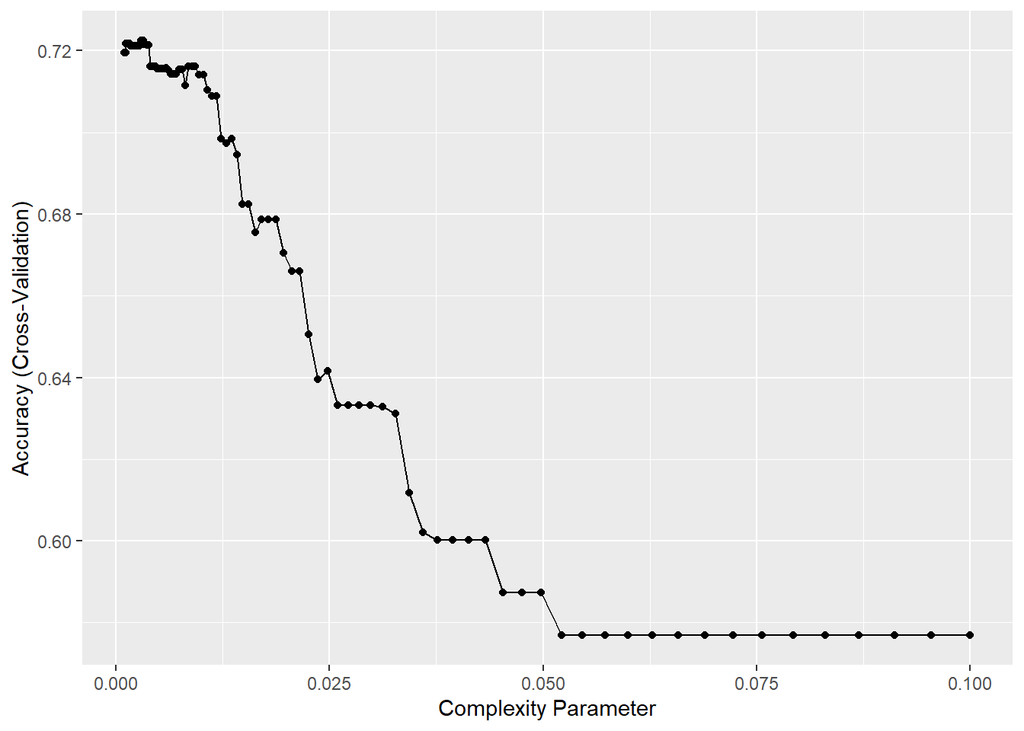

```r
set.seed(100)
tctrl <- trainControl(method = "cv",
                     number = 10,
                     verboseIter = FALSE,
                     sampling = "down")

cp = 10^seq(-3, -1, length = 100)

 model.tree<- train(Diabetes~.,
        data = train.data.2,
        method = "rpart",
        trControl = tctrl,
        tuneGrid = expand.grid(cp = cp)
  )

 ggplot(model.tree)
```

```r
model.tree$bestTune
```

```
##             cp
## 26 0.003199267
```

```r
#Obtain variable importance metrics
varImp(model.tree)
```

```
## rpart variable importance
##
##   only 20 most important variables shown (out of 33)
##
##                        Overall
## Age                   100.0000
## BMI                    67.0053
## Weight                 45.9515
## Pulse                  34.7497
## Height                 24.5217
## Race1White             22.8623
## HHIncomemore 99999     14.3674
## EducationSome College  10.9355
## PhysActiveYes           9.6011
## Smoke100Yes             6.5168
## HHIncome35000-44999     3.3019
## Race1Mexican            2.1967
## HHIncome45000-54999     1.9195
## EducationHigh School    1.5292
## HHIncome 5000-9999      1.2968
## HHIncome55000-64999     0.7185
## `HHIncome45000-54999`   0.0000
## `HHIncome25000-34999`   0.0000
## `HHIncome20000-24999`   0.0000
## `HHIncome65000-74999`   0.0000
```

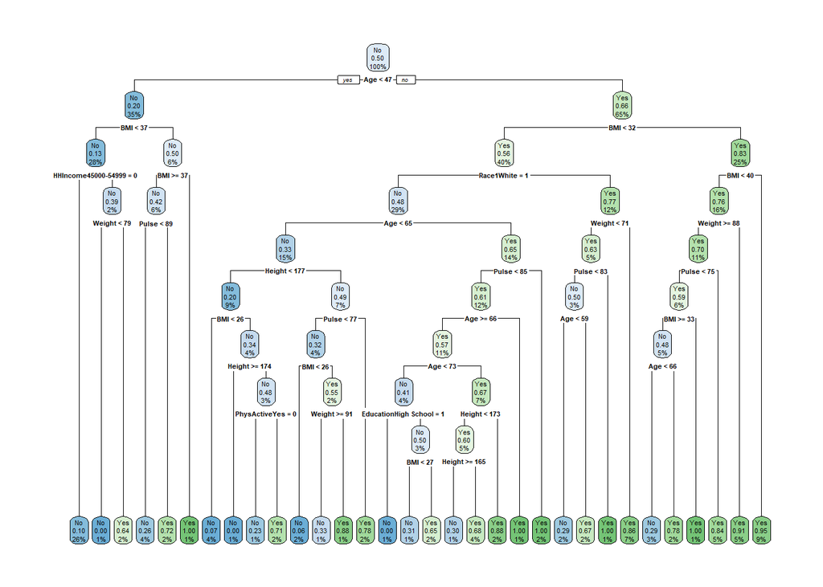

```r
#Visualize the tree
rpart.plot(model.tree$finalModel)
```

```r
#Estimate accuracy in the training data
confusionMatrix(model.tree)
```

```
## Cross-Validated (10 fold) Confusion Matrix
##
## (entries are percentual average cell counts across resamples)
##
##           Reference
## Prediction   No  Yes
##        No  64.3  2.4
##        Yes 25.3  8.0
##
##  Accuracy (average) : 0.7225
```

```r
#Estimate accuracy in the testing data
pred_diab<-predict(model.tree, test.data.2)
pred_diab_prob<- predict(model.tree, test.data.2, type = "prob")

confusionMatrix(pred_diab, test.data.2$Diabetes, positive = "Yes")
```

```
## Confusion Matrix and Statistics
##
##           Reference
## Prediction   No  Yes
##        No  1223   60
##        Yes  486  137
##
##                Accuracy : 0.7135
##                  95% CI : (0.6927, 0.7338)
##     No Information Rate : 0.8966
##     P-Value [Acc > NIR] : 1
##
##                   Kappa : 0.2101
##
##  Mcnemar's Test P-Value : <2e-16
##
##             Sensitivity : 0.69543
##             Specificity : 0.71562
##          Pos Pred Value : 0.21990
##          Neg Pred Value : 0.95323
##              Prevalence : 0.10336
##          Detection Rate : 0.07188
##    Detection Prevalence : 0.32686
##       Balanced Accuracy : 0.70553
##
##        'Positive' Class : Yes
##
```

```r
analysis <- roc(response=test.data.2$Diabetes, predictor=pred_diab_prob[,2])
```

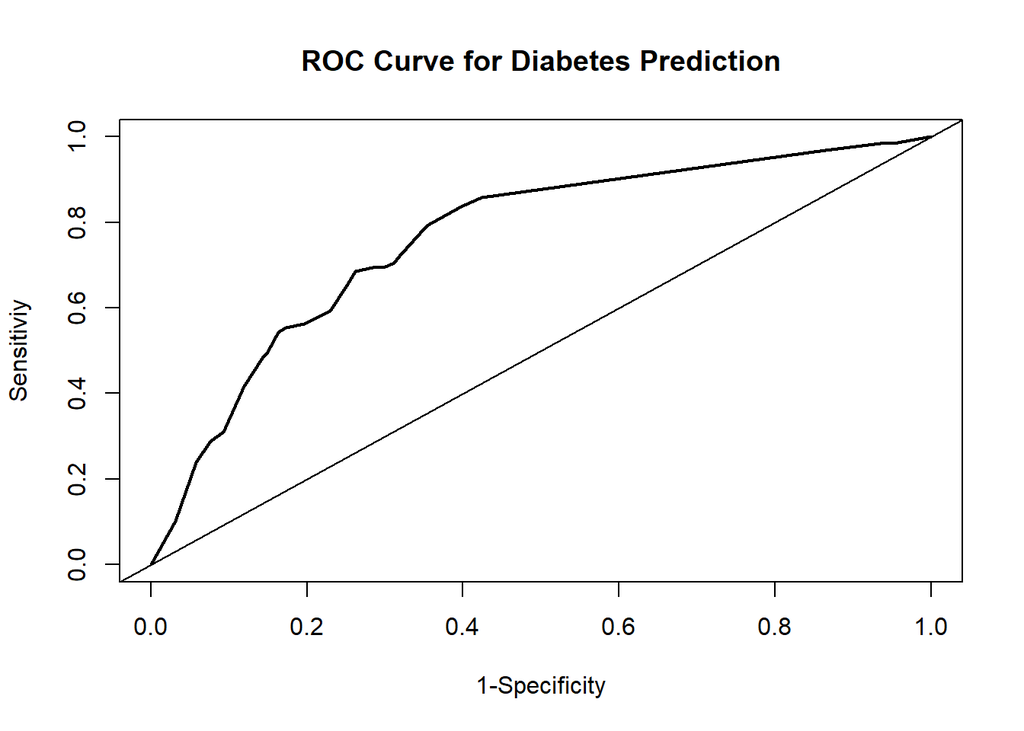

```r
plot(1-analysis$specificities,analysis$sensitivities,type="l",
ylab="Sensitiviy",xlab="1-Specificity",col="black",lwd=2,
main = "ROC Curve for Diabetes Prediction")
abline(a=0,b=1)
```

```r
## Using Area under the ROC curve to choose optimal model
set.seed(100)
control.settings.roc<-trainControl(method="cv", number=10, sampling="down", classProbs = TRUE, summaryFunction = twoClassSummary)
model.tree.roc<- train(Diabetes~.,
        data = train.data.2,
        method = "rpart",
        trControl = control.settings.roc,
        tuneGrid = expand.grid(cp = cp),
        metric="ROC"
  )

model.tree.roc$results
```

```
##              cp       ROC      Sens      Spec      ROCSD     SensSD     SpecSD
## 1   0.001000000 0.7866998 0.7156390 0.7531915 0.03476068 0.02775797 0.06672096
## 2   0.001047616 0.7866998 0.7156390 0.7531915 0.03476068 0.02775797 0.06672096
## 3   0.001097499 0.7866998 0.7156390 0.7531915 0.03476068 0.02775797 0.06672096
## 4   0.001149757 0.7866998 0.7156390 0.7531915 0.03476068 0.02775797 0.06672096
## 5   0.001204504 0.7839401 0.7186522 0.7488437 0.03828164 0.03003574 0.06911279
## 6   0.001261857 0.7839401 0.7186522 0.7488437 0.03828164 0.03003574 0.06911279
## 7   0.001321941 0.7839401 0.7186522 0.7488437 0.03828164 0.03003574 0.06911279
## 8   0.001384886 0.7839401 0.7186522 0.7488437 0.03828164 0.03003574 0.06911279
## 9   0.001450829 0.7839401 0.7186522 0.7488437 0.03828164 0.03003574 0.06911279
## 10  0.001519911 0.7839401 0.7186522 0.7488437 0.03828164 0.03003574 0.06911279
## 11  0.001592283 0.7839401 0.7186522 0.7488437 0.03828164 0.03003574 0.06911279
## 12  0.001668101 0.7834255 0.7176497 0.7509713 0.03827021 0.03045500 0.06929765
## 13  0.001747528 0.7834255 0.7176497 0.7509713 0.03827021 0.03045500 0.06929765
## 14  0.001830738 0.7834255 0.7176497 0.7509713 0.03827021 0.03045500 0.06929765
```

[output cut: 86 more lines]

```r
pred_diab.2<-predict(model.tree.roc, test.data.2)
confusionMatrix(pred_diab.2, test.data.2$Diabetes, positive="Yes")
```

```
## Confusion Matrix and Statistics
##
##           Reference
## Prediction   No  Yes
##        No  1223   60
##        Yes  486  137
##
##                Accuracy : 0.7135
##                  95% CI : (0.6927, 0.7338)
##     No Information Rate : 0.8966
##     P-Value [Acc > NIR] : 1
##
##                   Kappa : 0.2101
##
##  Mcnemar's Test P-Value : <2e-16
##
##             Sensitivity : 0.69543
##             Specificity : 0.71562
##          Pos Pred Value : 0.21990
##          Neg Pred Value : 0.95323
##              Prevalence : 0.10336
##          Detection Rate : 0.07188
##    Detection Prevalence : 0.32686
##       Balanced Accuracy : 0.70553
##
##        'Positive' Class : Yes
##
```